# test_stockassessment

##Setup

```r
library(tidyverse)
```

##Fmsy Equation

Test the Fmsy equation: Fmsy = r * (1 / (1+p)) - from the catchmsy function in R

```r
fmsy = 0.2 * (1/(1+0.2))
```

##Goals and Model

Initial Stock Assessment Test Goal: Simulate error around estimates of intial biomass

Write the function to include error in the biomass estimates. In this experiment the b_err term represents the estimated biomass with error. The biomass is randomly selected from a distribution where the mean is the actual biomass from the model and the standard deviation is 5% of the actual biomass from the model.

The basic function that we’ll use in the rest of these tests:

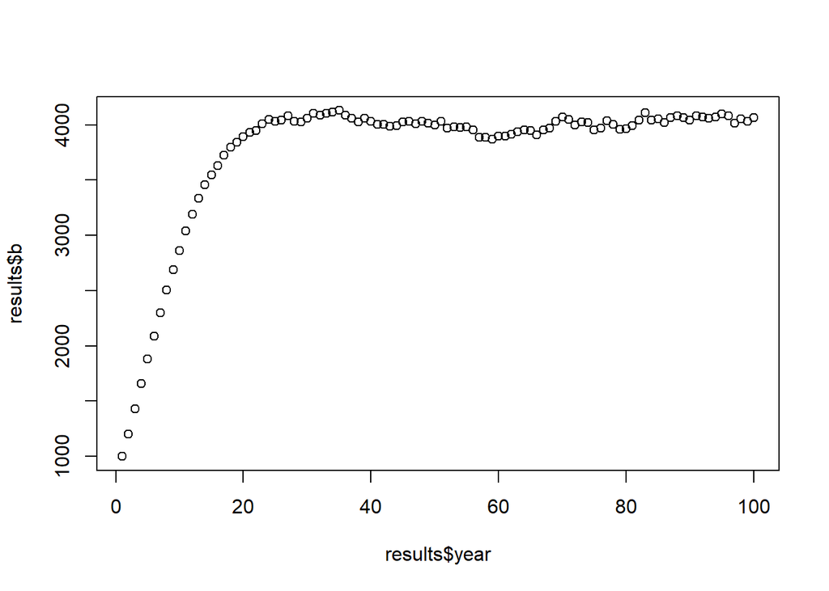

```r
#Write the function
sim_stockerror <- function(b, r, r_s, error, p, k, years){

  results <- data.frame(
    b = rep(NA, years), c = rep(NA, years),
    year = 1:years, r = rep(NA, years), b_err = rep(NA, years)) #Setup the results dataframe

  #Set the initial result for the outputs in year 1

  results$b[1] = b
  results$b_err[1] = rnorm(1, mean = results$b[1], sd = (error*results$b[1])) #simulate error in assessment
  results$c[1] = (r*(1/(1+p))) * results$b_err[1] #using f=Fmsy and b=estimate from initial stock assessment
  results$r[1] = r

  #Loop the model over the specified number of years
  for (t in 2:years) {

    results$b_err[t] = rnorm(1, mean = results$b[t-1], sd = (error*results$b[t-1]))
    results$c[t] = (r*(1/(1+p))) * results$b_err[t]
    results$b[t] = results$b[t-1] + (results$r[t-1] / p)*results$b[t-1]*(1 - ((results$b[t-1]/k) ^ p))-results$c[t]
    results$r[t] = results$r[1] * (1 + (r_s*(t-1)))

   }

  return(results)
}

#Test the results
results = sim_stockerror(b = 1000, r = 0.2, error = 0.05, p = 0.2,
                      years = 100, r_s = 0, k = 10000)


plot(results$year, results$b)
```

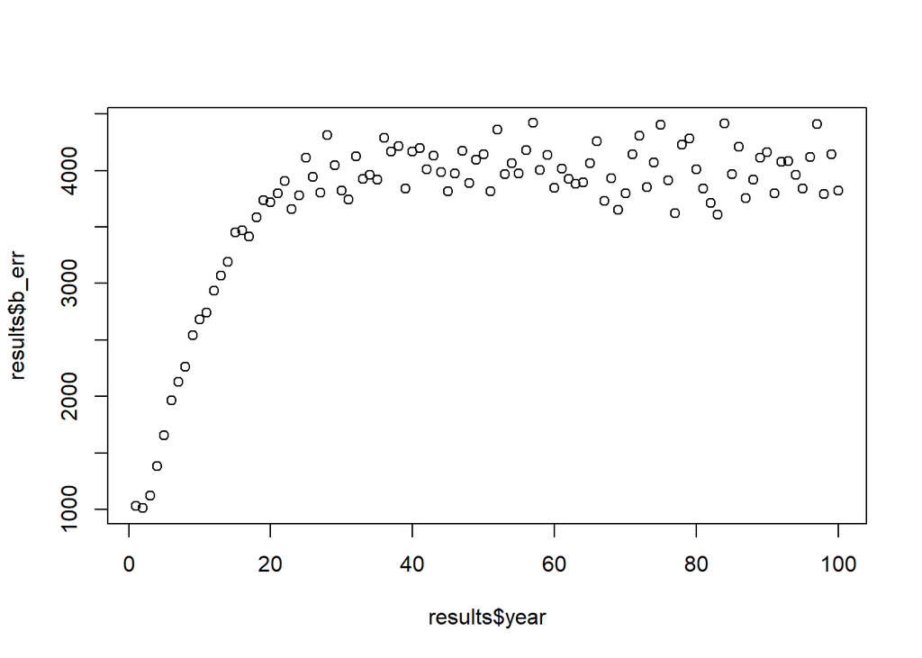

```r
plot(results$year, results$b_err)
```

##Goals Tests 1-4 Apply the new function to a set of experiments that vary actual initial biomass. In these experiments catch is responding to underlying changes in actual biomass but with some error. - Each test will change only the standard deviation associated with the error term

##Test 1 Standard deviation = 0.05

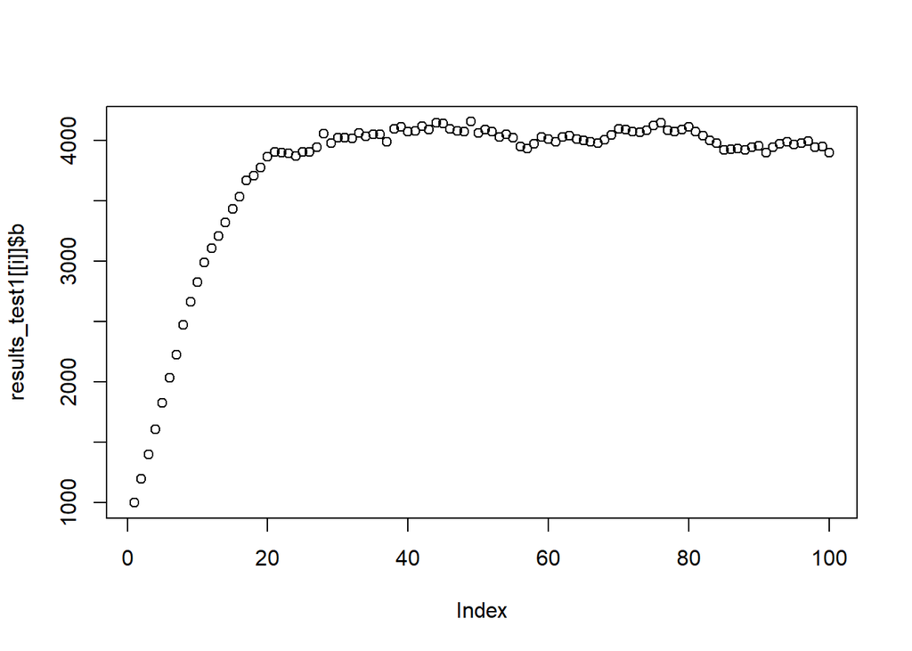

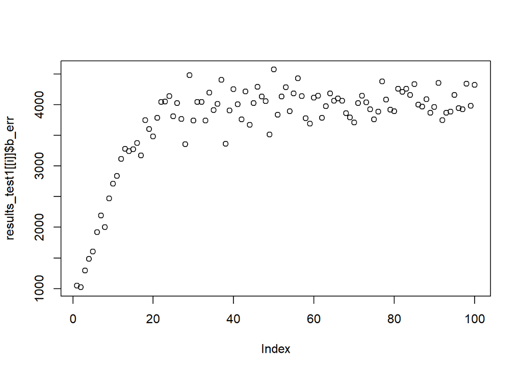

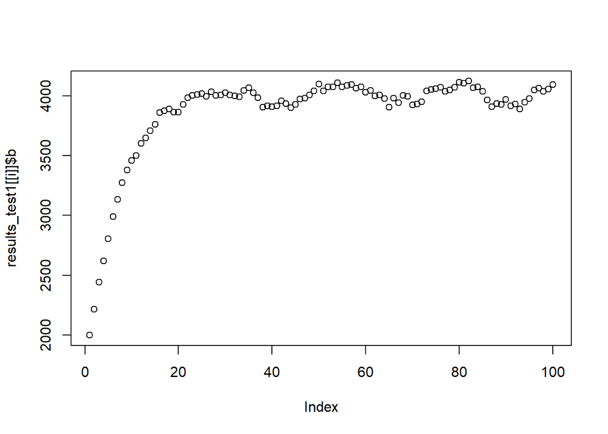

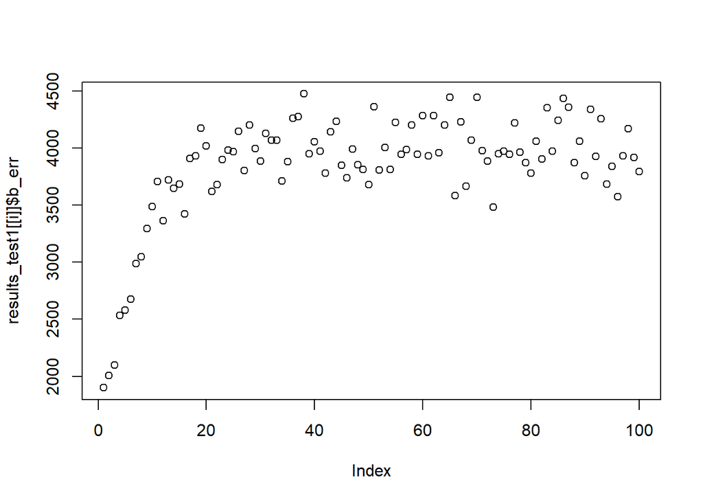

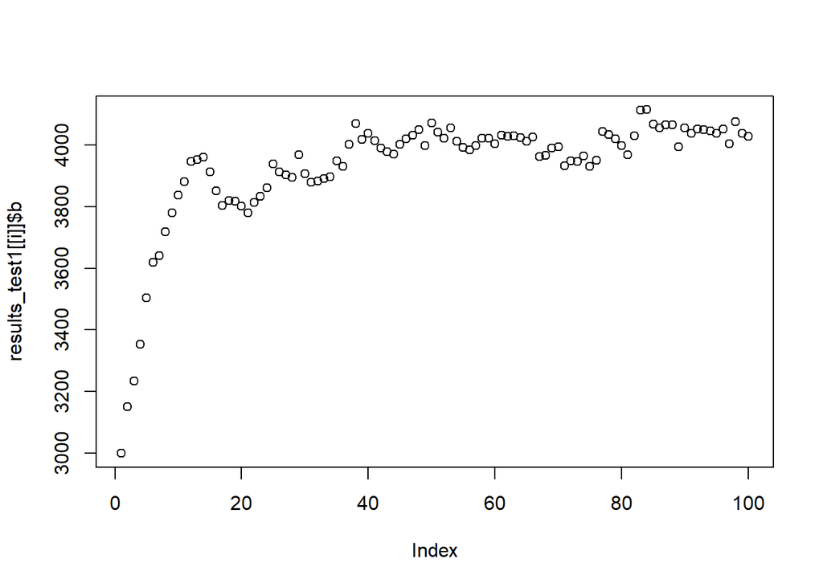

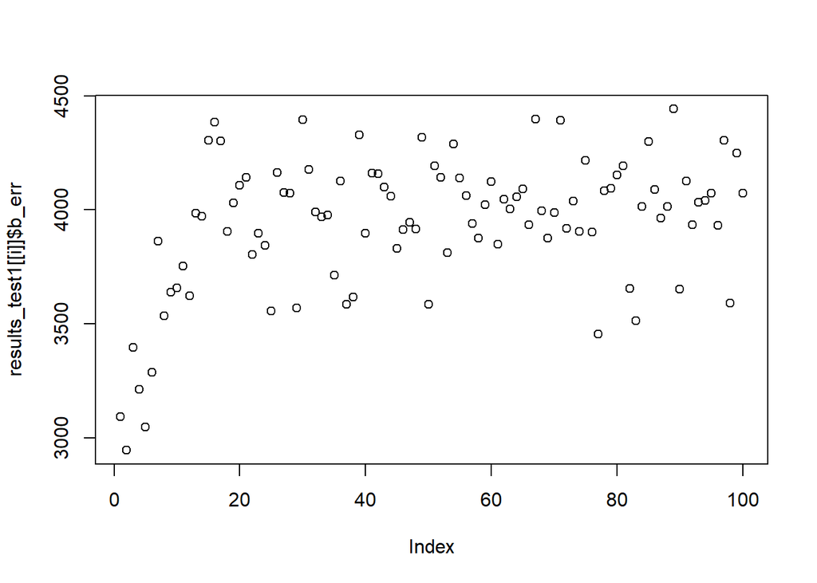

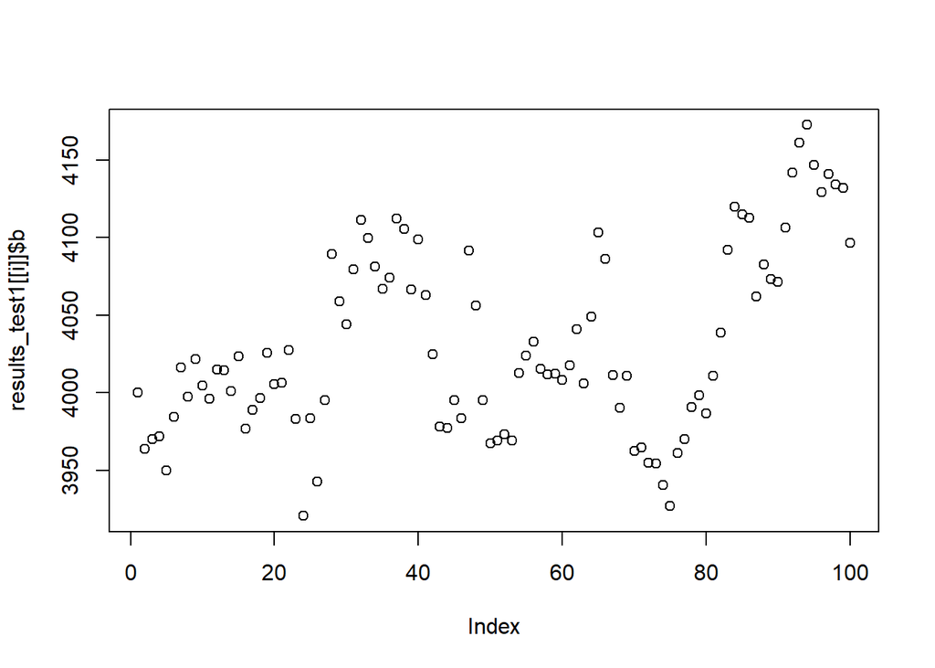

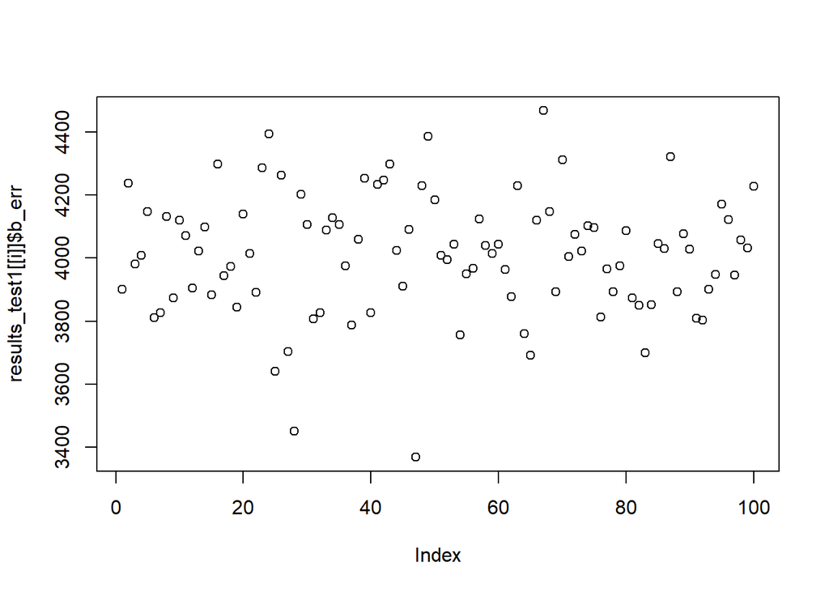

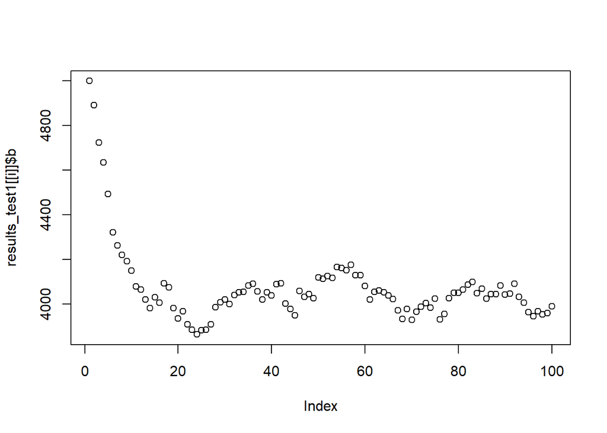

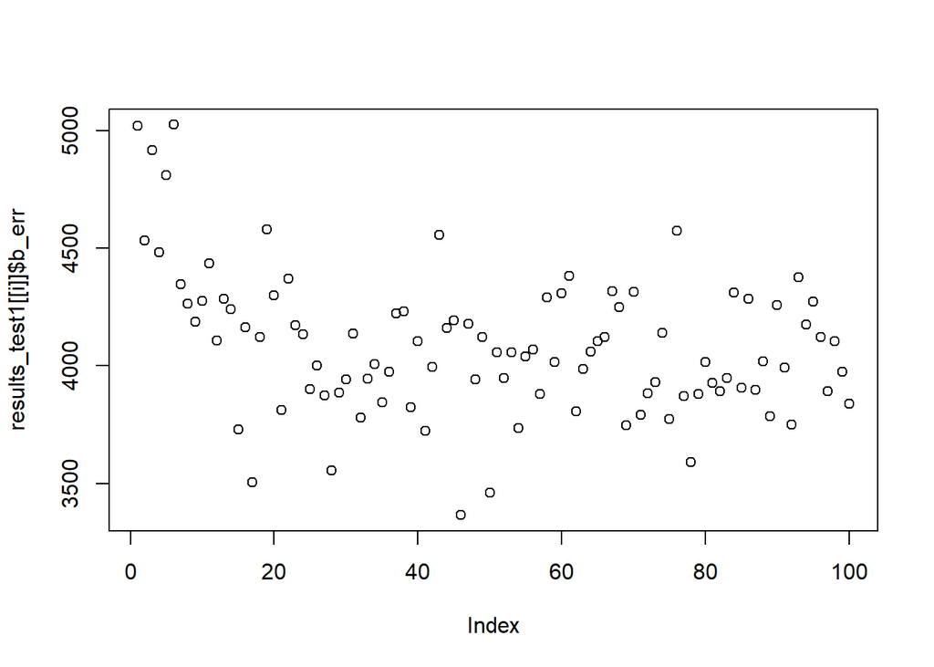

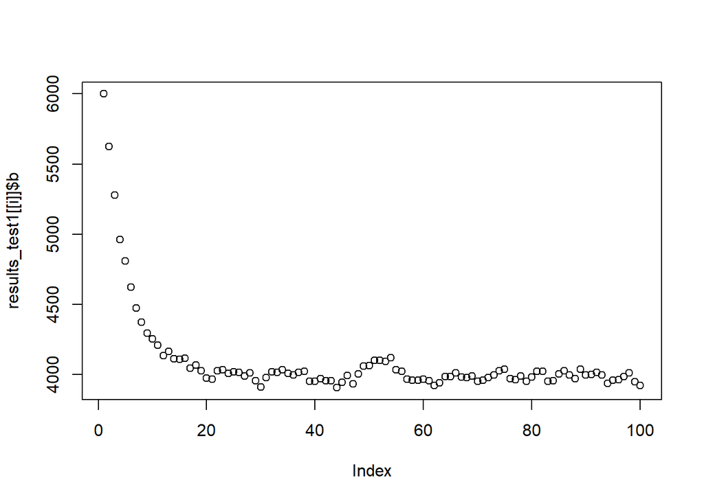

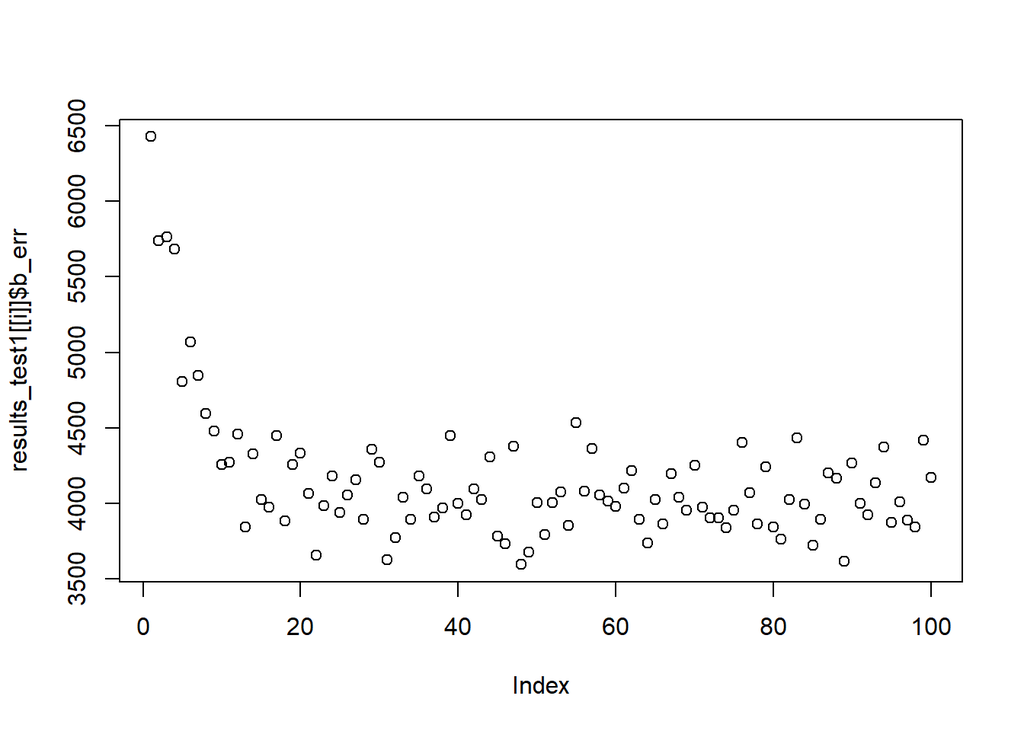

[8 more figures not shown]

```r
n_experiment = 10

#Input variables

experiment <- list(
  b = seq(1000, 10000, 1000),
  r = rep(0.2, n_experiment),
  r_s = rep(0, n_experiment),
  error = rep(0.05, n_experiment),
  p = rep(0.2, n_experiment),
  k = rep(10000, n_experiment),
  years = rep(100, n_experiment))

#Now apply to the function
results_test1 <- pmap(experiment, sim_stockerror)

#Plot results to see variation:
for(i in 1:n_experiment){
  plot(results_test1[[i]]$b)
  plot(results_test1[[i]]$b_err)
}
```

##Test 2 Standard deviation to 0.10

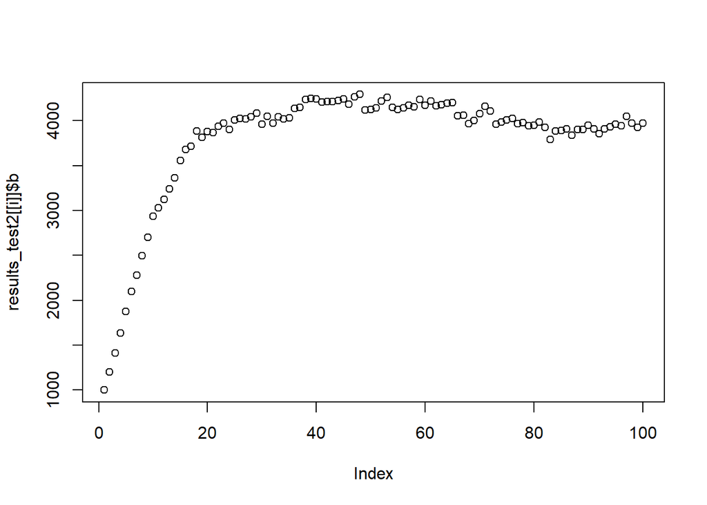

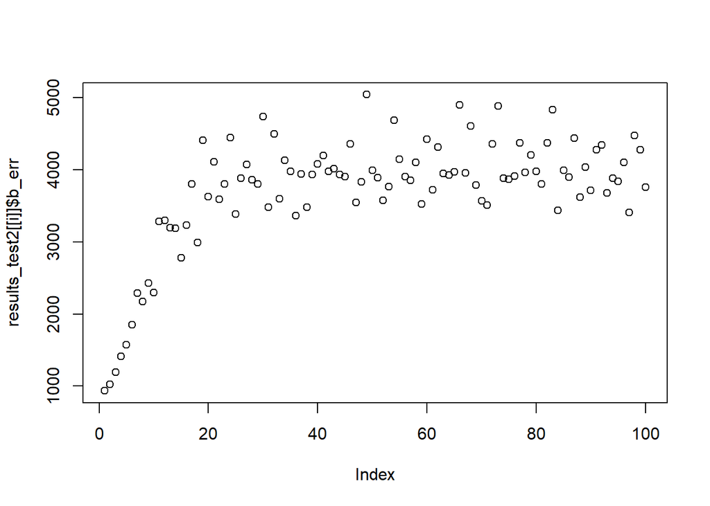

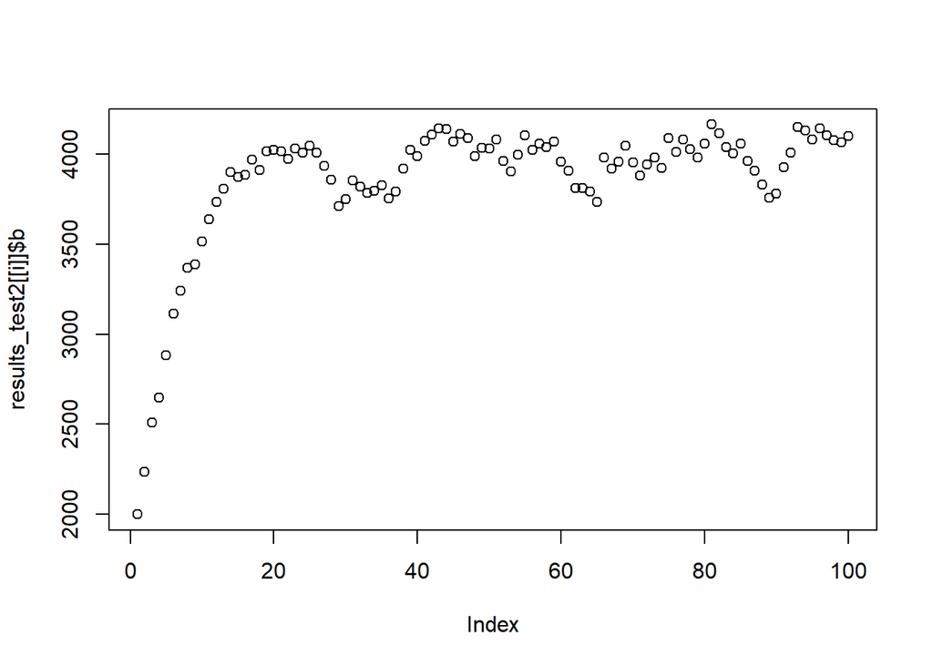

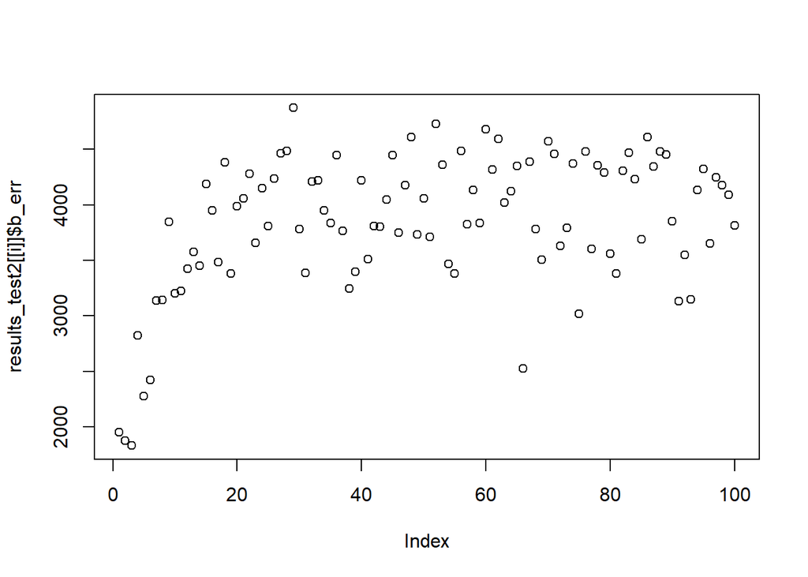

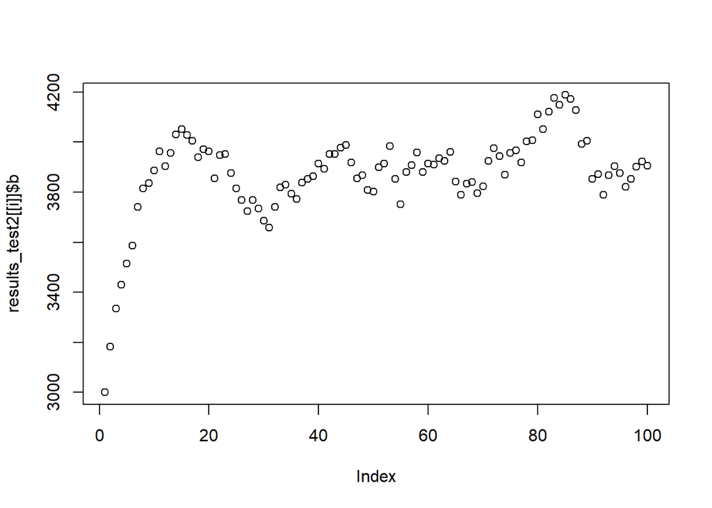

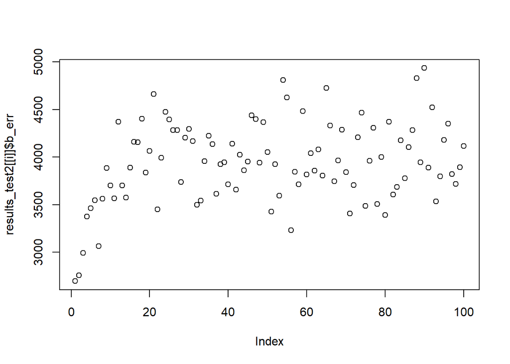

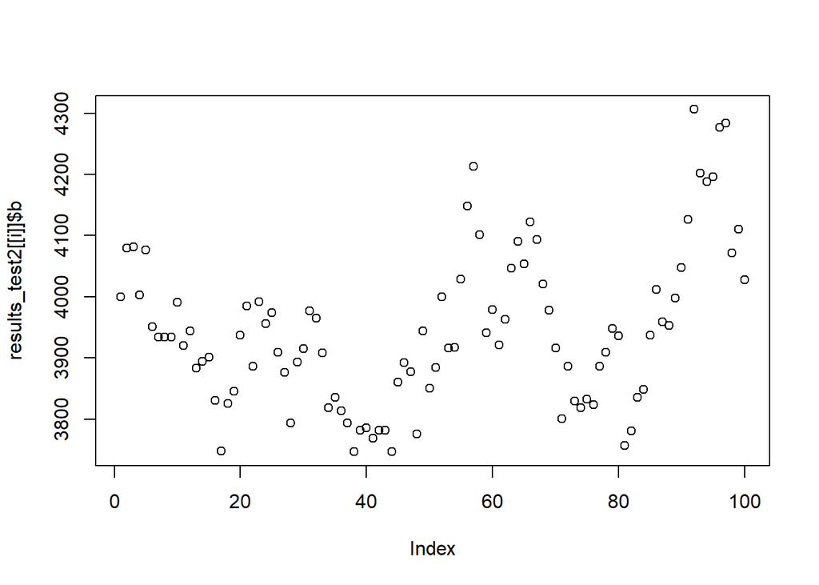

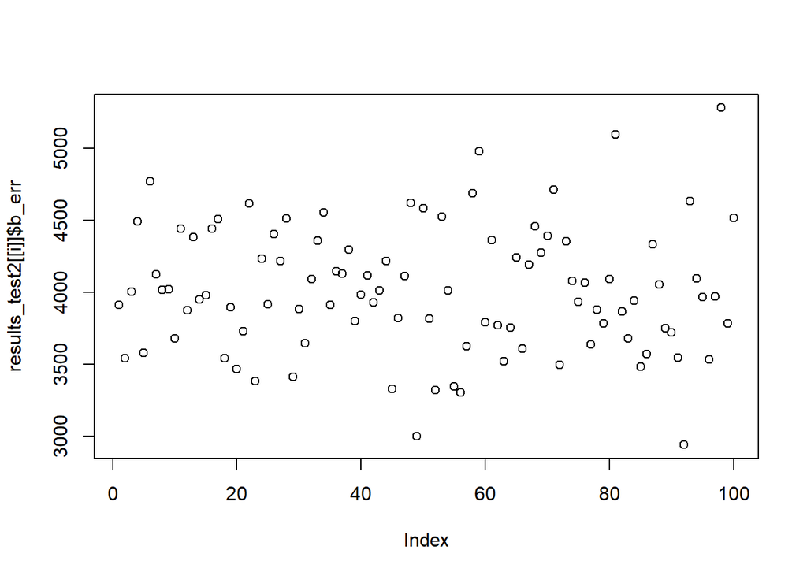

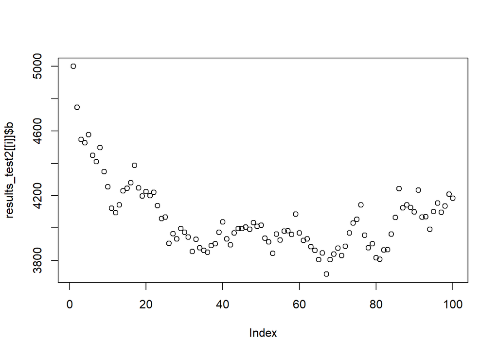

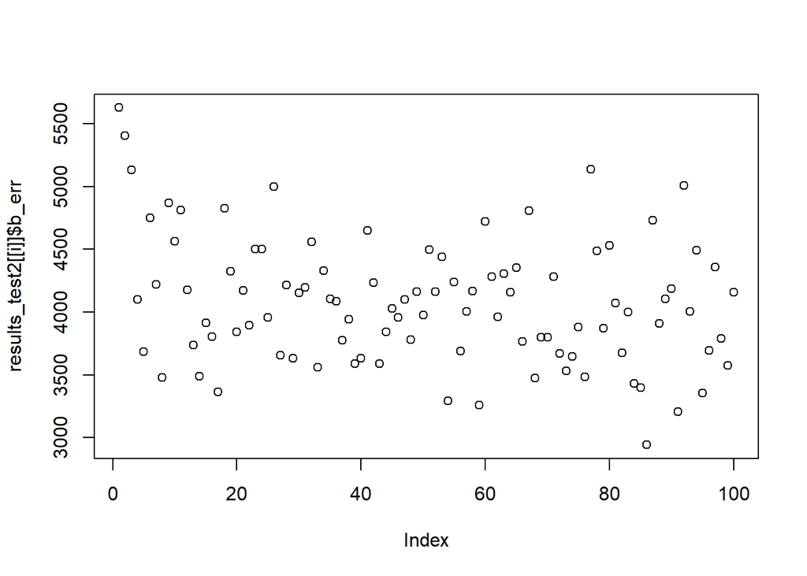

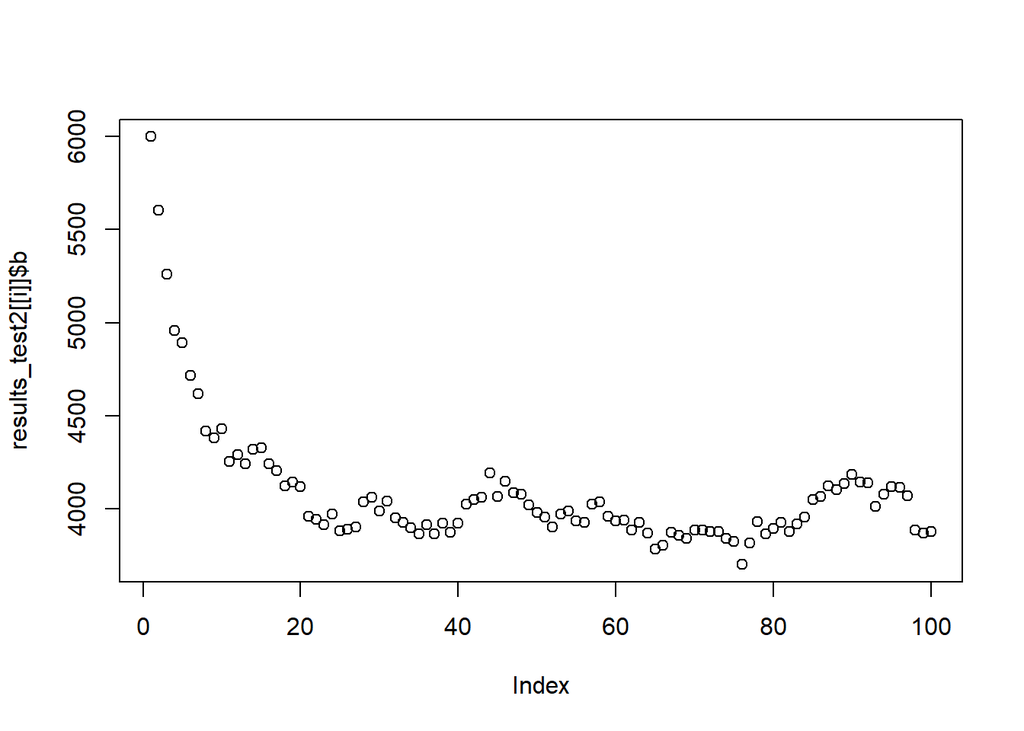

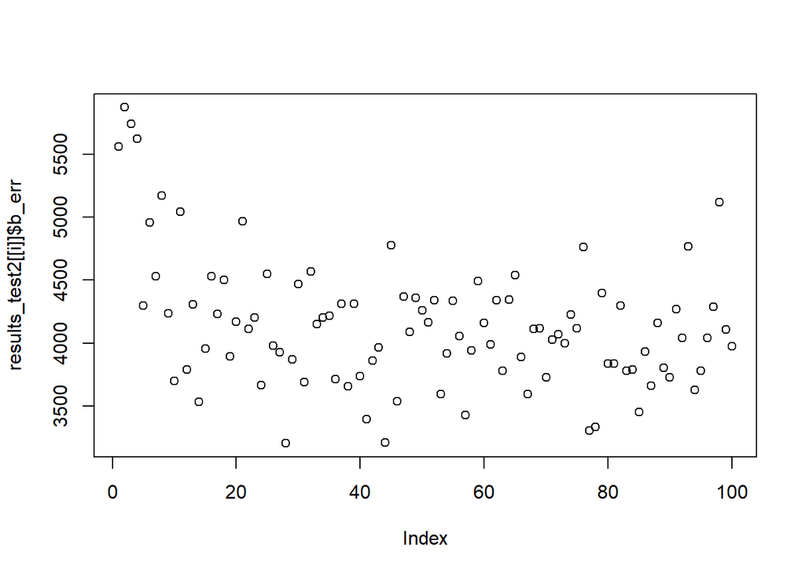

[8 more figures not shown]

```r
n_experiment = 10

#Input variables

experiment <- list(
  b = seq(1000, 10000, 1000),
  r = rep(0.2, n_experiment),
  r_s = rep(0, n_experiment),
  error = rep(0.1, n_experiment),
  p = rep(0.2, n_experiment),
  k = rep(10000, n_experiment),
  years = rep(100, n_experiment))

#Now apply to the function
results_test2 <- pmap(experiment, sim_stockerror)

#Plot results to see variation:
for(i in 1:n_experiment){
  plot(results_test2[[i]]$b)
  plot(results_test2[[i]]$b_err)
}
```

##Test 3 Standard deviation to 0.15